# Regresión lineal y logístia

Jesi Formoso

## Regresión

Busca describir los cambios en una variable respuesta (y) en función de los cambios en una variable predictora (x)

Funciones:

- Determnar como influye una variable sobre otra.
- Predecir valores no observados.

### Regresión lineal:

## Regresión lineal

Una variable respuesta (VD) numérica:

- Precio de una casa en Saratoga, NY

Uno o más predictores (VI):

- Cantidad de habitaciones
- Antigüedad de la propiedad
- Superficie

### Cargamos los datos!

```r
casas <- mosaicData::SaratogaHouses %>%
  select("precio" = price, "antigüedad" = age,
         "superficie" = livingArea, "habitaciones" = bedrooms,
         "calefaccion" = heating)

glimpse(casas)
```

```
## Rows: 1,728
## Columns: 5
## $ precio       <int> 132500, 181115, 109000, 155000, 86060, 120000, 153000, 1…
## $ antigüedad   <int> 42, 0, 133, 13, 0, 31, 33, 23, 36, 4, 123, 1, 13, 153, 9…
## $ superficie   <int> 906, 1953, 1944, 1944, 840, 1152, 2752, 1662, 1632, 1416…
## $ habitaciones <int> 2, 3, 4, 3, 2, 4, 4, 4, 3, 3, 7, 3, 2, 3, 3, 3, 3, 4, 2,…
## $ calefaccion  <fct> electric, hot water/steam, hot water/steam, hot air, hot…
```

### Exploramos las variables..

| missings |
| --- |
| 0 |

| variable | media | DE | min | max |
| --- | --- | --- | --- | --- |
| antigüedad | 27.92 | 29.21 | 0 | 225 |
| habitaciones | 3.15 | 0.82 | 1 | 7 |
| precio | 211966.71 | 98441.39 | 5000 | 775000 |
| superficie | 1754.98 | 619.94 | 616 | 5228 |

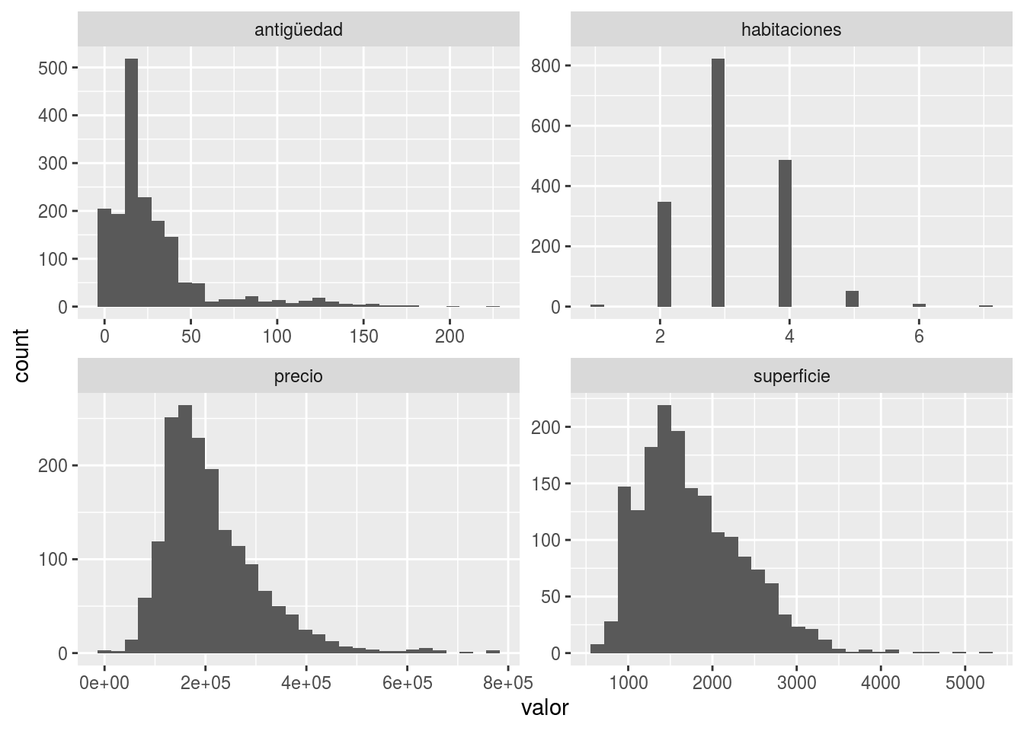

### ¿Las variables numéricas se asocian entre sí?

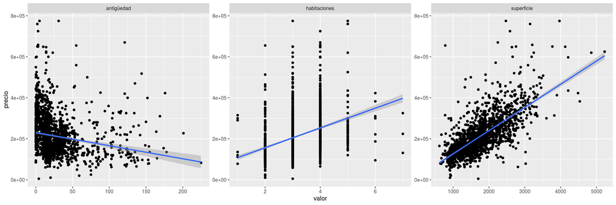

### Coeficientes de correlación:

```r
cor(casas$antigüedad,casas$precio)
```

```
## [1] -0.1887926
```

```r
cor(casas$superficie,casas$precio)
```

```
## [1] 0.7123902
```

```r
cor(casas$habitaciones,casas$precio)
```

```
## [1] 0.4003487
```

- ¿Cuál es la mejor combinación de variables para predecir el valor de una casa?
- ¿Qué tan bueno es mi modelo prediciendo ese valor?

### Dividimos el set de datos

```r
set.seed(123)

casas_split <- casas %>% initial_split(prop = .7)

casas_entrenamiento <- training(casas_split)
casas_testeo  <- testing(casas_split)

summary(casas_entrenamiento$precio)
```

```
##    Min. 1st Qu.  Median    Mean 3rd Qu.    Max.
##   10300  144050  189500  209867  256000  775000
```

```r
summary(casas_testeo$precio)
```

```
##    Min. 1st Qu.  Median    Mean 3rd Qu.    Max.
##    5000  149000  189950  216872  264250  775000
```

### Preparamos los datos para ser procesados:

- identificar, eliminar o imputar valores faltantes.
- convertir predictores categóricos en variables dummy.
- cambiar la escala de los datos.
- extraer datos de una variable (ej. texto o fechas)

### Armamos la receta

```r
casas_receta <- recipe(formula = precio ~ habitaciones + superficie + antigüedad, data = casas_entrenamiento) %>%
  step_center(all_numeric(), -all_outcomes()) %>%
  step_scale(all_numeric(), -all_outcomes()) %>%
  prep()

casas_receta
```

```
## Data Recipe
##
## Inputs:
##
##       role #variables
##    outcome          1
##  predictor          3
##
## Training data contained 1210 data points and no missing data.
##
## Operations:
##
## Centering for habitaciones, superficie, antigüedad [trained]
## Scaling for habitaciones, superficie, antigüedad [trained]
```

```r
casas_entrenamiento_prep <- bake(casas_receta, new_data = casas_entrenamiento)

casas_testeo_prep <- bake(casas_receta, new_data = casas_testeo)

glimpse(casas_entrenamiento_prep)
```

```
## Rows: 1,210
## Columns: 4
## $ habitaciones <dbl> -1.4241799, -0.1897546, 1.0446706, -0.1897546, -1.424179…
## $ superficie   <dbl> -1.3601222, 0.3245962, 0.3101144, 0.3101144, -1.4663222,…
## $ antigüedad   <dbl> 0.47057670, -0.94928364, 3.54694077, -0.50980306, -0.949…
## $ precio       <int> 132500, 181115, 109000, 155000, 86060, 153000, 90000, 12…
```

### Especificamos el modelo

1. Elegir el modelo –> linear_reg()
2. Elegir el engine –> set_engine()
3. Elegir el modo –> set_mode(): regresión o clasificación

```r
lm_modelo <- linear_reg() %>%
  set_engine('lm')

lm_ajuste <- lm_modelo %>%
  fit(precio ~ habitaciones,
      data = casas_entrenamiento_prep)

lm_ajuste
```

```
## parsnip model object
##
## Fit time:  2ms
##
## Call:
## stats::lm(formula = precio ~ habitaciones, data = data)
##
## Coefficients:
##  (Intercept)  habitaciones
##       209867         39029
```

### Exploramos el ajuste:

```r
tidy(lm_ajuste)
```

```
## # A tibble: 2 x 5
##   term         estimate std.error statistic  p.value
##   <chr>           <dbl>     <dbl>     <dbl>    <dbl>
## 1 (Intercept)   209867.     2542.      82.6 0.
## 2 habitaciones   39029.     2543.      15.3 1.03e-48
```

```r
glance(lm_ajuste)
```

```
## # A tibble: 1 x 12
##   r.squared adj.r.squared  sigma statistic  p.value    df  logLik    AIC    BIC
##       <dbl>         <dbl>  <dbl>     <dbl>    <dbl> <dbl>   <dbl>  <dbl>  <dbl>
## 1     0.163         0.163 88408.      236. 1.03e-48     1 -15497. 31001. 31016.
## # … with 3 more variables: deviance <dbl>, df.residual <int>, nobs <int>
```

### Evaluamos la precisión de nuestro modelo en un nuevo set de datos:

```r
resultado  <- lm_ajuste %>%
  predict(new_data = casas_testeo_prep) %>%
  bind_cols(casas_testeo_prep)

head(resultado)
```

```
## # A tibble: 6 x 5
##     .pred habitaciones superficie antigüedad precio
##     <dbl>        <dbl>      <dbl>      <dbl>  <int>
## 1 250639.        1.04      -0.964     0.0987 120000
## 2 250639.        1.04      -0.144    -0.172  170000
## 3 202461.       -0.190     -0.539    -0.814  122900
## 4 395174.        4.75       1.84      3.21   325000
## 5 154282.       -1.42      -1.69     -0.510   85860
## 6 202461.       -0.190     -1.31      2.03    89900
```

```r
rmse(resultado, truth = precio, estimate=.pred)
```

```
## # A tibble: 1 x 3
##   .metric .estimator .estimate
##   <chr>   <chr>          <dbl>
## 1 rmse    standard      94430.
```

```r
mae(resultado, truth = precio, estimate=.pred)
```

```
## # A tibble: 1 x 3
##   .metric .estimator .estimate
##   <chr>   <chr>          <dbl>
## 1 mae     standard      65070.
```

```r
rsq(resultado, truth = precio, estimate = .pred)
```

```
## # A tibble: 1 x 3
##   .metric .estimator .estimate
##   <chr>   <chr>          <dbl>
## 1 rsq     standard       0.155
```

### Con todos los predictores

```r
lm_ajuste2 <- lm_modelo %>%
  fit(precio ~ antigüedad + superficie + habitaciones,
      data = casas_entrenamiento_prep)

tidy(lm_ajuste2)
```

```
## # A tibble: 4 x 5
##   term         estimate std.error statistic   p.value
##   <chr>           <dbl>     <dbl>     <dbl>     <dbl>
## 1 (Intercept)   209867.     1891.    111.   0.
## 2 antigüedad     -5744.     1959.     -2.93 3.42e-  3
## 3 superficie     75622.     2581.     29.3  5.61e-143
## 4 habitaciones  -10061.     2544.     -3.96 8.09e-  5
```

```r
resultado2  <- lm_ajuste2 %>%
  predict(new_data = casas_testeo_prep) %>%
  bind_cols(casas_testeo_prep)

head(resultado2)
```

```
## # A tibble: 6 x 5
##     .pred habitaciones superficie antigüedad precio
##     <dbl>        <dbl>      <dbl>      <dbl>  <int>
## 1 125868.        1.04      -0.964     0.0987 120000
## 2 189480.        1.04      -0.144    -0.172  170000
## 3 175655.       -0.190     -0.539    -0.814  122900
## 4 282716.        4.75       1.84      3.21   325000
## 5  99688.       -1.42      -1.69     -0.510   85860
## 6 100935.       -0.190     -1.31      2.03    89900
```

```r
rmse(resultado2, truth = precio, estimate=.pred)
```

```
## # A tibble: 1 x 3
##   .metric .estimator .estimate
##   <chr>   <chr>          <dbl>
## 1 rmse    standard      74221.
```

```r
#rmse  anterior: 94430

mae(resultado2, truth = precio, estimate=.pred)
```

```
## # A tibble: 1 x 3
##   .metric .estimator .estimate
##   <chr>   <chr>          <dbl>
## 1 mae     standard      49875.
```

```r
# mae anterior: 65070
```

## Regresión logística

Una variable respuesta (VD) binaria:

- Si la persona está viva o no 20 años después de la observación inicial.

Uno o más predictores (VI):

- Si fuma
- Su edad

```r
fumar <- mosaicData::Whickham %>%
  select("muerte" = outcome, "fuma" = smoker,
         "edad" = age) %>%
  mutate(muerte = as_factor(ifelse(muerte == "Dead", 1, 0)))

glimpse(fumar)
```

```
## Rows: 1,314
## Columns: 3
## $ muerte <fct> 0, 0, 1, 0, 0, 0, 0, 1, 0, 0, 0, 0, 0, 1, 0, 0, 1, 0, 0, 0, 1,…
## $ fuma   <fct> Yes, Yes, Yes, No, No, Yes, Yes, No, No, No, No, Yes, No, Yes,…
## $ edad   <int> 23, 18, 71, 67, 64, 38, 45, 76, 28, 27, 28, 34, 20, 72, 48, 45…
```

```r
fumar %>% count(fuma, muerte)
```

```
##   fuma muerte   n
## 1   No      0 502
## 2   No      1 230
## 3  Yes      0 443
## 4  Yes      1 139
```

### Dividimos el set de datos

```r
set.seed(123)

fumar_split <- fumar %>% initial_split(prop = .7)

fumar_entrenamiento <- training(fumar_split)
fumar_testeo  <- testing(fumar_split)

fumar_entrenamiento %>%
  count(fuma) %>%
  mutate(prop = n/sum(n))
```

```
##   fuma   n      prop
## 1   No 516 0.5608696
## 2  Yes 404 0.4391304
```

```r
fumar_testeo  %>%
  count(fuma) %>%
  mutate(prop = n/sum(n))
```

```
##   fuma   n      prop
## 1   No 216 0.5482234
## 2  Yes 178 0.4517766
```

### Generamos la receta:

```r
glm_receta <-
  recipe(fuma ~ ., fumar_entrenamiento) %>%
  step_normalize(edad) %>%
  prep()

glm_receta
```

```
## Data Recipe
##
## Inputs:
##
##       role #variables
##    outcome          1
##  predictor          2
##
## Training data contained 920 data points and no missing data.
##
## Operations:
##
## Centering and scaling for edad [trained]
```

### Aplicamos la receta a los datos:

```r
fumar_entrenamiento_prep <- bake(glm_receta, new_data = fumar_entrenamiento)

fumar_testeo_prep <- bake(glm_receta, new_data = fumar_testeo)
```

### Especificamos y ajustamos el modelo

```r
glm_modelo <-
  logistic_reg(mode = "classification") %>%
  set_engine(engine = "glm") %>%
  fit(muerte ~ ., data = fumar_entrenamiento_prep)

glm_modelo
```

```
## parsnip model object
##
## Fit time:  7ms
##
## Call:  stats::glm(formula = muerte ~ ., family = stats::binomial, data = data)
##
## Coefficients:
## (Intercept)         edad      fumaYes
##     -1.7839       2.1124       0.1886
##
## Degrees of Freedom: 919 Total (i.e. Null);  917 Residual
## Null Deviance:       1090
## Residual Deviance: 668.7     AIC: 674.7
```

### ¿Qué tan bueno es nuestro modelo clasificando?

```r
glm_predicciones <- glm_modelo %>%
  predict(new_data = fumar_testeo_prep) %>%
  bind_cols(fumar_testeo_prep %>% select(muerte))

glm_predicciones
```

```
## # A tibble: 394 x 2
##    .pred_class muerte
##    <fct>       <fct>
##  1 1           1
##  2 0           0
##  3 0           0
##  4 0           0
##  5 0           0
##  6 1           0
##  7 0           1
##  8 0           0
##  9 0           0
## 10 1           1
## # … with 384 more rows
```

### Accuracy, precision, recall, F1_score:

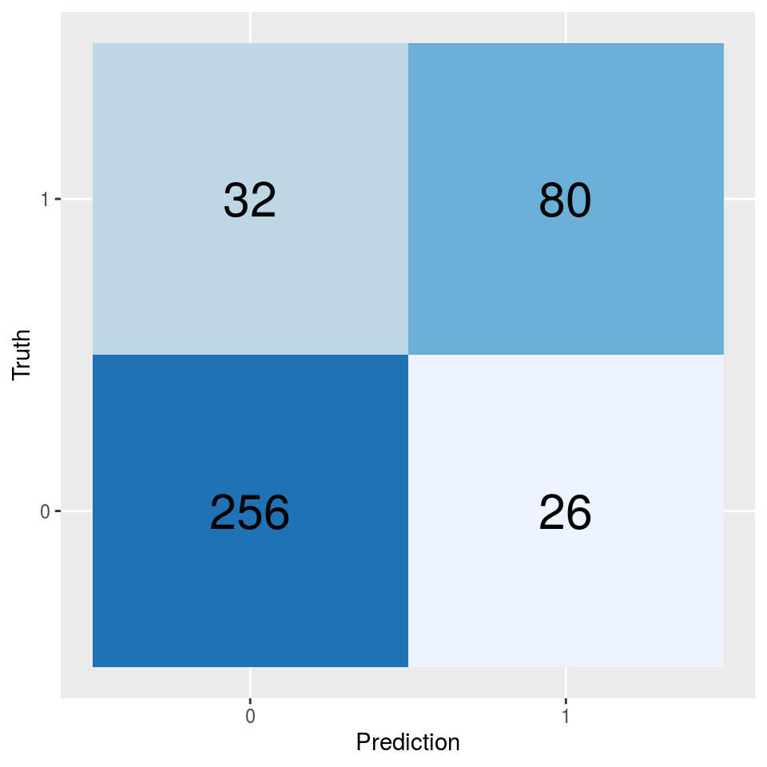

```r
glm_predicciones %>%
  conf_mat(muerte, .pred_class) %>%
  pluck(1) %>%
  as_tibble() %>%
  ggplot(aes(Prediction, Truth, fill = as_factor(n))) +
  geom_tile(show.legend = FALSE) +
  scale_fill_brewer() +
  geom_text(aes(label = n), size = 8)
```

### Accuracy: proporción de casos correctamente clasificados por el modelo:

```r
glm_predicciones %>%
  metrics(muerte, .pred_class) %>%
  select(-.estimator) %>%
  filter(.metric == "accuracy")
```

```
## # A tibble: 1 x 2
##   .metric  .estimate
##   <chr>        <dbl>
## 1 accuracy     0.853
```

### Precisión (falsos positivos) y recall (falsos negativos):

```r
tibble(
  "precisión" =
     precision(glm_predicciones, muerte, .pred_class) %>%
     select(.estimate),
  "recall" =
     recall(glm_predicciones, muerte, .pred_class) %>%
     select(.estimate)
) %>%
  unnest() %>%
  kable()
```

| precisión | recall |
| --- | --- |
| 0.8888889 | 0.9078014 |

### F1_score

```r
glm_predicciones %>%
  f_meas(muerte, .pred_class) %>%
  select(-.estimator) %>%
  kable()
```

| .metric | .estimate |
| --- | --- |
| f_meas | 0.8982456 |